# Native DuckDB vs. direct parquet querying performance

## Introduction

This page reports the results of a controlled benchmarking experiment comparing query performance between two approaches to storing and querying the same data using the DuckDB package in R: a **native DuckDB database** and **direct Parquet files** queried via `read_parquet()`. Both formats contain identical data drawn from three California city subsets of the [Stanford Open Policing Project](https://openpolicing.stanford.edu/) (Pierson et al. 2023) — Los Angeles, San Francisco, and San Jose — sourced from the same MySQL database. The only difference between the two approaches is the storage format itself. In both methods, DuckDB is used to execute the queries. Direct Parquet file querying means that DuckDB reads the .parquet files directly from disk on every query execution, without first loading the data into a database: the files remain as standalone compressed columnar files and DuckDB parses, decompresses, and queries them in place each time a query is run.

For background on Parquet’s internal structure and how DuckDB reads files directly, see the Theoretical Foundations Resource on File Formats & DuckDB. Also for an more on direct Parquet querying check out the Theory in Practice Parquet Querying Time Exploration

| Query | Description |
| --- | --- |
| **Q1** | `COUNT(*)` — total row count across a single city |
| **Q2** | `GROUP BY subject_race` — aggregation on one column, single city |
| **Q3** | `GROUP BY type` — aggregation on a different column, single city |
| **Q4** | String filter — `ILIKE` pattern match on a string column |
| **Q5** | Cross-table `GROUP BY subject_race` — aggregation across all three cities |

Note that Q2 - Q5 are also all `COUNT(*)` tasks, but with additional constraints.

Each timing result is the **mean of 20 timed runs**, preceded by 3 warmup runs. A fresh DuckDB connection is opened and closed for every trial to avoid connection-level caching effects.

### Statistical significance

Differences between native DuckDB and direct Parquet are tested using a **two-sided Wilcoxon rank-sum test** at α = 0.05. This non-parametric test is appropriate here because query times are non-negative, right-skewed, and not guaranteed to follow a normal distribution. A result marked **Yes** indicates the observed difference in timing distributions is statistically unlikely to have occurred by chance, and we can conclude the two approaches differ meaningfully in performance for that query. A result marked **No** means the difference is not statistically distinguishable from random variation.

## Setup

```r
library(arrow)
library(duckdb)
library(DBI)
library(dplyr)
library(tidyr)
library(ggplot2)
library(here)
library(RMySQL)
```

## Step 1: Build storage formats

One concrete advantage of direct Parquet over native DuckDB is storage footprint. Because Parquet files are written with columnar compression applied at the column level, they are typically substantially smaller than an equivalent DuckDB database, which stores data in its own internal format optimized for query performance rather than disk compactness.

```r
Sys.setenv(MARIADB_TLS_DISABLE_PEER_VERIFICATION = 1)

con_traffic <- DBI::dbConnect(
  RMySQL::MySQL(),
  dbname = "traffic",
  host = Sys.getenv("TRAFFIC_HOST"),
  user = Sys.getenv("TRAFFIC_USER"),
  password = Sys.getenv("TRAFFIC_PWD")
)

tables <- c(
  "ca_los_angeles_2020_04_01",
  "ca_san_francisco_2020_04_01",
  "ca_san_jose_2020_04_01"
)
short_names <- c("la", "sf", "sj")

# ── Write one Parquet file per city ──
dir.create(here::here("parquet_cities"), showWarnings = FALSE)

for (i in seq_along(tables)) {
  cat("Reading", tables[i], "from MySQL...\n")
  df <- dbReadTable(con_traffic, tables[i])
  outfile <- here::here("parquet_cities", paste0(short_names[i], ".parquet"))
  write_parquet(df, outfile)
  cat("  Written:", outfile, "\n")
  rm(df)
  gc()
}
```

```
Reading ca_los_angeles_2020_04_01 from MySQL...
  Written: /Users/jsh04747/gitRepos/StatEd/sql4stats/parquet_cities/la.parquet
Reading ca_san_francisco_2020_04_01 from MySQL...
  Written: /Users/jsh04747/gitRepos/StatEd/sql4stats/parquet_cities/sf.parquet
Reading ca_san_jose_2020_04_01 from MySQL...
  Written: /Users/jsh04747/gitRepos/StatEd/sql4stats/parquet_cities/sj.parquet
```

```r
# ── Build native DuckDB — one table per city ──
con_native <- dbConnect(duckdb(), here::here("traffic_native.duckdb"))

for (i in seq_along(tables)) {
  cat("Loading", tables[i], "into DuckDB...\n")
  df <- dbReadTable(con_traffic, tables[i])
  dbWriteTable(con_native, short_names[i], df, overwrite = TRUE)
  cat("  Rows written:", nrow(df), "\n")
  rm(df)
  gc()
}
```

```
Loading ca_los_angeles_2020_04_01 into DuckDB...
  Rows written: 5418402
Loading ca_san_francisco_2020_04_01 into DuckDB...
  Rows written: 905070
Loading ca_san_jose_2020_04_01 into DuckDB...
  Rows written: 152834
```

```r
cat("\nTables in native DuckDB:\n")
```

```
Tables in native DuckDB:
```

```r
print(dbListTables(con_native))
```

```
[1] "la"      "sf"      "sj"      "traffic"
```

```r
dbDisconnect(con_native, shutdown = TRUE)
dbDisconnect(con_traffic)
```

```
[1] TRUE
```

```r
cat("Done.\n")
```

```
Done.
```

## Step 2: Storage size comparison

One concrete advantage of direct Parquet over native DuckDB is storage footprint and size. Because Parquet files are written with columnar compression applied at the column level, they are typically substantially smaller than an equivalent DuckDB database, which stores data in its own internal format optimized for query performance rather than disk compactness.

```r
parquet_files <- list.files(
  here::here("parquet_cities"),
  pattern = "\\.parquet$",
  full.names = TRUE
)
parquet_size_mb <- round(sum(file.size(parquet_files)) / 1e6, 2)
parquet_size_gb <- round(parquet_size_mb / 1000, 3)

duckdb_size_mb <- round(file.size(here::here("traffic_native.duckdb")) / 1e6, 2)
duckdb_size_gb <- round(duckdb_size_mb / 1000, 3)

ratio <- round(duckdb_size_mb / parquet_size_mb, 2)

size_df <- data.frame(
  Format = c("Direct Parquet (3 files)", "Native DuckDB (1 file)"),
  `Size (MB)` = c(parquet_size_mb, duckdb_size_mb),
  `Size (GB)` = c(parquet_size_gb, duckdb_size_gb),
  `Files` = c(3, 1),
  `Ratio vs. Parquet` = c(1.00, ratio)
)

knitr::kable(
  size_df,
  align = "r",
  caption = "Storage size comparison: direct Parquet vs. native DuckDB"
)
```

Storage size comparison: direct Parquet vs. native DuckDB

| Format | Size..MB. | Size..GB. | Files | Ratio.vs..Parquet |
| --- | --- | --- | --- | --- |
| Direct Parquet (3 files) | 90.24 | 0.090 | 3 | 1.00 |
| Native DuckDB (1 file) | 197.93 | 0.198 | 1 | 2.19 |

Beyond storage size, direct Parquet also avoids the ingestion step entirely. The data can be queried immediately after the Parquet files are written, with no loading or database construction required. The trade-off is query performance, which the remainder of this page explores.

## Step 3: Benchmark

This section contains the code for creating the queries and obtaining the mean times for each query. In this code, 5 queries were performed and are meant to represent varying forms of queries, from counting rows to cross-table queries. The first code chunk defines the paruqet files and the 5 queries.

```r
la_parquet <- here::here("parquet_cities", "la.parquet")
sf_parquet <- here::here("parquet_cities", "sf.parquet")
sj_parquet <- here::here("parquet_cities", "sj.parquet")

queries <- list(
  Q1 = list(
    label = "COUNT(*) — LA only",
    direct = sprintf("SELECT COUNT(*) FROM read_parquet('%s')", la_parquet),
    native = "SELECT COUNT(*) FROM la"
  ),

  Q2 = list(
    label = "GROUP BY subject_race — LA only",
    direct = sprintf(
      "SELECT subject_race, COUNT(*) AS n FROM read_parquet('%s') GROUP BY subject_race ORDER BY n DESC",
      la_parquet
    ),
    native = "SELECT subject_race, COUNT(*) AS n FROM la GROUP BY subject_race ORDER BY n DESC"
  ),

  Q3 = list(
    label = "GROUP BY type — LA only",
    direct = sprintf(
      "SELECT type, COUNT(*) AS n FROM read_parquet('%s') GROUP BY type ORDER BY n DESC",
      la_parquet
    ),
    native = "SELECT type, COUNT(*) AS n FROM la GROUP BY type ORDER BY n DESC"
  ),

  Q4 = list(
    label = "String filter ILIKE — LA only",
    direct = sprintf(
      "SELECT COUNT(*) FROM read_parquet('%s') WHERE raw_descent_description ILIKE '%%hispanic%%'",
      la_parquet
    ),
    native = "SELECT COUNT(*) FROM la WHERE raw_descent_description ILIKE '%hispanic%'"
  ),

  Q5 = list(
    label = "Cross-table GROUP BY subject_race — all three cities",
    direct = sprintf(
      "SELECT subject_race, COUNT(*) AS n FROM (
         SELECT subject_race FROM read_parquet('%s')
         UNION ALL
         SELECT subject_race FROM read_parquet('%s')
         UNION ALL
         SELECT subject_race FROM read_parquet('%s')
       ) GROUP BY subject_race ORDER BY n DESC",
      la_parquet,
      sf_parquet,
      sj_parquet
    ),
    native = "SELECT subject_race, COUNT(*) AS n FROM (
         SELECT subject_race FROM la
         UNION ALL
         SELECT subject_race FROM sf
         UNION ALL
         SELECT subject_race FROM sj
       ) GROUP BY subject_race ORDER BY n DESC"
  )
)
```

```r
fresh_direct <- function() dbConnect(duckdb())
fresh_native <- function() {
  dbConnect(duckdb(), here::here("traffic_native.duckdb"))
}

n_warmup <- 3
n_trials <- 20

run_trials <- function(con_fn, sql, n_warmup, n_trials) {
  for (i in seq_len(n_warmup)) {
    con <- con_fn()
    try(dbGetQuery(con, sql), silent = TRUE)
    try(dbDisconnect(con, shutdown = TRUE), silent = TRUE)
    gc()
  }
  times_ms <- numeric(n_trials)
  for (i in seq_len(n_trials)) {
    con <- con_fn()
    tryCatch(
      {
        times_ms[i] <- system.time(dbGetQuery(con, sql))["elapsed"] * 1000
      },
      error = function(e) {
        times_ms[i] <<- NA
      },
      finally = {
        try(dbDisconnect(con, shutdown = TRUE), silent = TRUE)
      }
    )
    gc()
  }
  times_ms
}

all_trials <- data.frame(
  query_id = character(),
  label = character(),
  format = character(),
  trial = integer(),
  time_ms = numeric()
)

for (qid in names(queries)) {
  q <- queries[[qid]]
  cat("\nRunning", qid, "—", q$label, "\n")

  cat("  Native...\n")
  nt <- run_trials(fresh_native, q$native, n_warmup, n_trials)
  cat("  Native mean:", round(mean(nt, na.rm = TRUE), 1), "ms\n")

  cat("  Direct...\n")
  dt <- run_trials(fresh_direct, q$direct, n_warmup, n_trials)
  cat("  Direct mean:", round(mean(dt, na.rm = TRUE), 1), "ms\n")

  all_trials <- rbind(
    all_trials,
    data.frame(
      query_id = qid,
      label = q$label,
      format = "native",
      trial = seq_len(n_trials),
      time_ms = round(nt, 3)
    ),
    data.frame(
      query_id = qid,
      label = q$label,
      format = "direct",
      trial = seq_len(n_trials),
      time_ms = round(dt, 3)
    )
  )
}
```

```
Running Q1 — COUNT(*) — LA only
  Native...
```

```
  Native mean: 0.8 ms
  Direct...
```

```
  Direct mean: 1.1 ms

Running Q2 — GROUP BY subject_race — LA only
  Native...
```

```
  Native mean: 4.7 ms
  Direct...
  Direct mean: 8.6 ms

Running Q3 — GROUP BY type — LA only
  Native...
  Native mean: 4.9 ms
  Direct...
  Direct mean: 9.2 ms

Running Q4 — String filter ILIKE — LA only
  Native...
  Native mean: 5.6 ms
  Direct...
  Direct mean: 23 ms

Running Q5 — Cross-table GROUP BY subject_race — all three cities
  Native...
  Native mean: 6.2 ms
  Direct...
  Direct mean: 9.8 ms
```

## Results

### Summary table

```r
summary_df <- all_trials %>%
  group_by(query_id, label, format) %>%
  summarise(
    mean_ms = round(mean(time_ms, na.rm = TRUE), 1),
    .groups = "drop"
  ) %>%
  pivot_wider(names_from = format, values_from = mean_ms) %>%
  mutate(
    diff_ms = round(direct - native, 1),
    ratio = round(direct / native, 2),
    faster = ifelse(native < direct, "Native", "Direct Parquet")
  )

# Add significance test
sig_col <- mapply(
  function(qid) {
    nt <- all_trials %>%
      filter(query_id == qid, format == "native") %>%
      pull(time_ms)
    dt <- all_trials %>%
      filter(query_id == qid, format == "direct") %>%
      pull(time_ms)
    p <- tryCatch(
      wilcox.test(nt, dt, exact = FALSE)$p.value,
      error = function(e) NA
    )
    ifelse(!is.na(p) & p < 0.05, "Yes", "No")
  },
  summary_df$query_id
)

summary_df$significant <- sig_col

knitr::kable(
  summary_df %>%
    select(label, native, direct, diff_ms, ratio, faster, significant),
  col.names = c(
    "Query",
    "Native (ms)",
    "Direct (ms)",
    "Diff (ms)",
    "Ratio (D/N)",
    "Faster",
    "Sig. (p < 0.05)"
  ),
  align = c("l", "r", "r", "r", "r", "l", "c"),
  caption = "Mean query time: native DuckDB vs. direct Parquet. Ratio > 1 means direct Parquet is slower. Significance assessed via Wilcoxon rank-sum test."
)
```

Mean query time: native DuckDB vs. direct Parquet. Ratio > 1 means direct Parquet is slower. Significance assessed via Wilcoxon rank-sum test.

| Query | Native (ms) | Direct (ms) | Diff (ms) | Ratio (D/N) | Faster | Sig. (p < 0.05) |
| --- | --- | --- | --- | --- | --- | --- |
| COUNT(*) — LA only | 0.8 | 1.0 | 0.2 | 1.25 | Native | Yes |
| GROUP BY subject_race — LA only | 4.7 | 8.6 | 3.9 | 1.83 | Native | Yes |
| GROUP BY type — LA only | 4.9 | 9.2 | 4.3 | 1.88 | Native | Yes |
| String filter ILIKE — LA only | 5.7 | 23.0 | 17.3 | 4.04 | Native | Yes |
| Cross-table GROUP BY subject_race — all three cities | 6.2 | 9.8 | 3.6 | 1.58 | Native | Yes |

### Visual representation

The chart below shows the direct/native ratio for each query type. A ratio above 1 (dashed line) means direct Parquet was slower than native DuckDB for that query; below 1 means direct Parquet was faster.

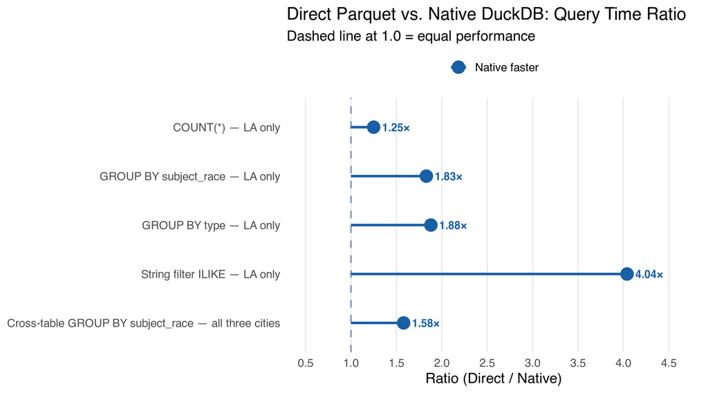

Direct-to-native query time ratio by query type. Ratio > 1 indicates native DuckDB is faster; ratio < 1 indicates direct Parquet is faster.

```r
plot_df <- summary_df %>%
  mutate(
    label = factor(label, levels = rev(label)),
    color_grp = ifelse(ratio > 1, "Native faster", "Direct faster")
  )

ggplot(plot_df, aes(x = ratio, y = label, colour = color_grp)) +
  geom_vline(
    xintercept = 1,
    linetype = "dashed",
    colour = "#94a3b8",
    linewidth = 0.8
  ) +
  geom_segment(
    aes(x = 1, xend = ratio, y = label, yend = label),
    linewidth = 1.1
  ) +
  geom_point(size = 5) +
  geom_text(
    aes(label = sprintf("%.2f×", ratio)),
    hjust = ifelse(plot_df$ratio > 1, -0.3, 1.3),
    size = 3.5,
    fontface = "bold"
  ) +
  scale_colour_manual(
    values = c("Native faster" = "#185FA5", "Direct faster" = "#0F6E56")
  ) +
  scale_x_continuous(
    limits = c(
      min(0.5, min(plot_df$ratio) * 0.85),
      max(1.5, max(plot_df$ratio) * 1.15)
    ),
    breaks = seq(0, 10, by = 0.5)
  ) +
  labs(
    x = "Ratio (Direct / Native)",
    y = NULL,
    colour = NULL,
    title = "Direct Parquet vs. Native DuckDB: Query Time Ratio",
    subtitle = "Dashed line at 1.0 = equal performance"
  ) +
  theme_minimal(base_size = 13) +
  theme(
    legend.position = "top",
    panel.grid.major.y = element_blank(),
    panel.grid.minor = element_blank()
  )
```

## Conclusion

The results can be understood based on the knowledge of how DuckDB querying and direct Parquet querying functions. When data is ingested into a native DuckDB database, DuckDB builds and maintains its own internal columnar storage format, statistics, and metadata that are optimized specifically for its query engine. When a query runs against a native table, DuckDB can exploit these internals directly, for example, reading only the pages it needs, using pre-computed column statistics, and operating entirely within a single file with no coordination overhead. Direct Parquet querying, by contrast, requires DuckDB to open each file, parse its footer, decompress column chunks, and assemble results from separate sources on every query execution. Even though Parquet is also columnar and compressed, this per-query parsing and file-handling overhead adds time that the native format avoids entirely.